# 218034

*N* removed NAs: 3

*N* removed typo: 1

*N* removed <18: 29

*N* total clean: 117

| Group | *N* | *M*<sub>age</sub> | *M*<sub>rating</sub> |
| --- | --- | --- | --- |
| Control | 59 | 21.75 | 5.44 |
| Experim | 58 | 20.90 | 6.53 |

**Main analysis results**

*t*(115) = -6.76, *p* < .001

[interactive chart not shown]

[figure not shown]

[interactive chart not shown]

# 218034

Analysing Data, Spring 2020

# Methods

## Participants

One-hundred and fifty participants initially submitted data to contribute to this experiment. Participants in the control (white-frame) condition had the mean age of 21.75, with a standard deviation of 2.70. Within the experimental condition (red-frame) the mean age is reported as 20.90, with a standard deviation of 2.26. The range of ages is reported to be 18-28. However, this data is reflective of after participants were removed due to several reasons. One was to meet the age requirement being 18+ years (n = 29). Participants with NA values were also removed (n = 3) as well as one participant who had a typo ‘1y’ as their age. The final number of people that was included is 117.

Table 1 *Descriptive statistics Age by Condition*

| Condition | *N* | % | *M*<sub>age</sub> | *SD*<sub>age</sub> |
| --- | --- | --- | --- | --- |
| control | 59 | 50.43 | 21.75 | 2.70 |
| experimental | 58 | 49.57 | 20.90 | 2.26 |

## Design

The research question in this is ‘Does colour influence attractiveness?’. The analysis of variables that will be conducted in the present research will be operationalised. The Independent variable, in this case, was the two colour conditions (factor with 2 levels) control and experimental. The control condition incorporated a white frame around the picture while the experimental displayed a red frame. The dependent variable was the ratings of attractiveness as a numeric value from 1 (lowest) - 9 (highest). They were based on three items which were then interpreted as a composite score. Variables such as age (numeric value) and ID (factor with 117 levels) were also recorded.The operational hypothesis of the research was whether the colour of the frame could influence the composite score of the mean attractiveness ratings of a moderately attractive man.

# Results

Generally the results indicate that there is a difference in attraction ratings in the different colour conditions. The experimental red-frame group (6.53) had higher mean attraction rating than the control white-frame group (5.44) (refer to Figure.1). The standard deviation of the groups are (0.96) and (0.77) respectively (refer to Figure. 2).

With the use of an independent *t*-test, analysis on whether different colour conditions would influence the mean ratings of attractiveness was possible. The test concluded that the means in the two conditions differed largely. (*M*<sub>diff</sub> = -1.09 ,95% CI [ -1.41, -0.77] and there was a significant difference between the two groups of ratings of liking (*t*(115) = -6.76, *p* = .00000000061).

The difference between the means is figuratively big. Therefore, we can infer that they were in two different conditions. If the condition has no affect on the ratings of attractiveness and these means come from the same population, the probability of obtaining the obtained t-value with the difference of means would be 0. We can observe through a t-distribution and the degrees of freedom (115), the probability of obtaining this t-value ( .00000000061) is less than .05. Thus, it is sensible to conclude that we should reject the null hypothesis and accept the alternative hypothesis that the different colour conditions make a difference to how much people find others attractive.

The big confidence intervals also indicate the range of values for 95% of intervals that will contain the true population value. The lower and higher intervals are both negative, this is evidence 0 does not lie in the confidence interval. This means the true difference in means could not be 0.

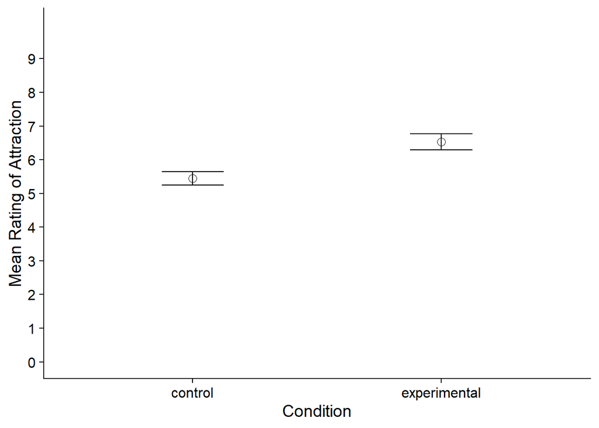

**Figure 1** Composite scores of Mean rating of Attraction by Condition

Table 2 *Descriptive statistics Attraction by Condition*

| Condition | *N* | % | *M*<sub>attraction</sub> | *SD*<sub>attraction</sub> |
| --- | --- | --- | --- | --- |
| control | 59 | 50.43 | 5.44 | 0.77 |
| experimental | 58 | 49.57 | 6.53 | 0.96 |

**Figure 2** Descriptive statistics Attraction by Condition

# Discussion

Although some numerous replications and results also account for the colour red effect on attractiveness (Francis, 2013, p.292), other research in the area still challenges this idea. Francis (2013) claimed that Elliot et al. (2010) has publication bias. This was proposed as the experiments themselves lacked power (probability of rejecting the null hypothesis). As sample sizes were small, the probability of rejecting the null hypothesis for all 12 findings was .005. Therefore, it seemed appropriate to claim there was publication bias. However, Elliot & Maier (2013) had responded to the criticism, acknowledging the lack of power; they replicated the experiment with 144 participants to find inconclusive results. Also, they addressed the publication bias issue in psychology was an issue but defended that there was no publication bias within their research. Thus, questions the probability of how replicable the results of the original study and the present replication is. This weakens the evidence of the colour red-effect on attractiveness.

Replication of experiment 1 from Hesslinger et al. (2015) replicated the study with both genders and found that there was no statistical significance between the small differences of the means. The same results were found even when split by gender (p. 1144-1145). Peperkoorn et al. (2016) also found the insignificance of the colour red effect on attractiveness when rating the attractiveness of women in different coloured clothing. This further question whether the results of this present replication are always consistent and the effect of colour on attractiveness rating. Strength and weaknesses will also need to be evaluated to grasp whether this replication was successful in contributing to the broader knowledge of this research area. A particular strength is that the present replication has more power than the original study, due to larger sample size. This allows for the standard error of the t-distribution to be smaller than the original study, increasing reliability of the results of the t-test. Therefore, the present replication could be seen as more reliable evidence that the colour red affects ratings of attractiveness.

However, since this study is a majorly based off of Elliot et al. (2010), it also shares weaknesses. The most significant point of weakness is ecological validity and confounding variables. The experiment lacks ecological validity as it fails to consider many other different factors that inform the real-life judgement of attractiveness. Hesslinger et al. (2015) conducted a second experiment with the same procedure, but with the addition of different apparel styles as a variable. They found that the apparel styles made a significant difference in ratings rather than the colour of the frame. Also, other variables such as the subtlety of facial expressions or posture with the presentation of the colour red are yet to be accounted for when rating attractiveness (Elliot & Maier, 2013, p.298).

To conclude, statistically, this replication has been able to replicate the results of the original study and shown evidence of the positive effect of the colour red on attractiveness. The findings find a similar difference in means and prove that results are statistically significant. However, research in the area may include publication bias or have been able to find insignificant results, questioning whether these results always replicate. Also, considering the lack of ecological validity and confounding variables (such as expressions and posture), it is too soon to determine that colour effect on attractiveness is real. Further research should try and provide more substantial evidence, replicating experiments multiple times with more power ad a larger sample size. Implementations to observe the effect of apparel style, posture and expressions should also be present.

# References

Elliot, A. J., & Maier, M. A. (2013). The red-attractiveness effect, applying the Ioannidis and Trikalinos (2007b) test, and the broader scientific context: A reply to Francis (2013). Journal of Experimental Psychology: General, 142(1), 297–300. https://doi.org/10.1037/a0029592

Elliot, A. J., Niesta Kayser, D., Greitemeyer, T., Lichtenfeld, S., Gramzow, R. H., Maier, M. A., & Liu, H. (2010). Red, rank, and romance in women viewing men. Journal of Experimental Psychology: General, 139(3), 399–417. https://doi.org/10.1037/a0019689

Francis, G. (2013). Publication bias in “Red, rank, and romance in women viewing men,” by Elliot et al. (2010). Journal of Experimental Psychology: General, 142(1), 292–296. http://dx.doi.org/10.1037/a0027923

Hesslinger, V. M., Goldbach, L., & Carbon, C.-C. (2015). Men in red: A reexamination of the red-attractiveness effect. Psychonomic Bulletin & Review, 22(4), 1142–1148. https://doi.org/10.3758/s13423-015-0866-8

Peperkoorn, L. S., Roberts, S. C., & Pollet, T. V. (2016). Revisiting the Red Effect on Attractiveness and Sexual Receptivity: No Effect of the Color Red on Human Mate Preferences. Evolutionary Psychology, 14(4), 1474704916673841. https://doi.org/10.1177/1474704916673841